# The Use of Elo Scores for Determining Level Difficulty

## Highlights

- Elo is moderately correlated with gmpu ($\rho = 0.55, *p* = 1.931e-09$)
- Elo is more strongly correlated with the *number of times a level was left unsolved* ($\rho = 0.398$) compared to GMPU ($\rho = -0.012$)
- Elo scores are more strongly correlated with the *mean duration to solve a level* ($\rho = 0.766, *p* < 2.2e-16$) than GMPU ($\rho = 0.629, *p* = 7.227e-12$)

## What’s in the dataset

I specifically define variables are they are being introduced, but I want to make especially clear the scope of the log data. The log data for Before/After is what I have been pulling from Learning Locker over the last year. I have made various large (>3gb) downloads to ensure I always had the more accurate and comprehensive snapshot of what is in Learning Locker. Last month I took a day to merge all the copies that I had and ensure there were no duplicate values. The current log file I use runs from 05-10-2019 to 04-19-2021.

## Elo Ratings

The Elo scores are created by updating the score every time a player solves or fails to solve a level. In other words, the Elo algorithm runs through the list of observations. When a player solves a level, the Elo is decreased for that level and the player’s Elo is increased. Elo scores start at 1500 and move up or down based on the results.

Elo assumes that performances (i.e., chess matches) are random. Players can play better or worse, but overtime the distribution will be normal. Therefore, our use of Elo for determining level difficulties is dependent on data collected over time. The more gameplay data we can collect, the more accurate our difficulty ratings are going to be. This is why, even though the studies differ, we use data from both the Big Study (linear, adaptive, and control conditions) and the Before/After study.

Given Elo’s assumption of random normal distributions, it’s worth checking if the scores we found were normal. The histogram below is of Elos cores. The center line is the mean and the left and right vertical lines are +/- 1 SD from the mean. That’s pretty normal. If there is any skew it would be a mild positive skew as fewer players to beat the hardest levels.

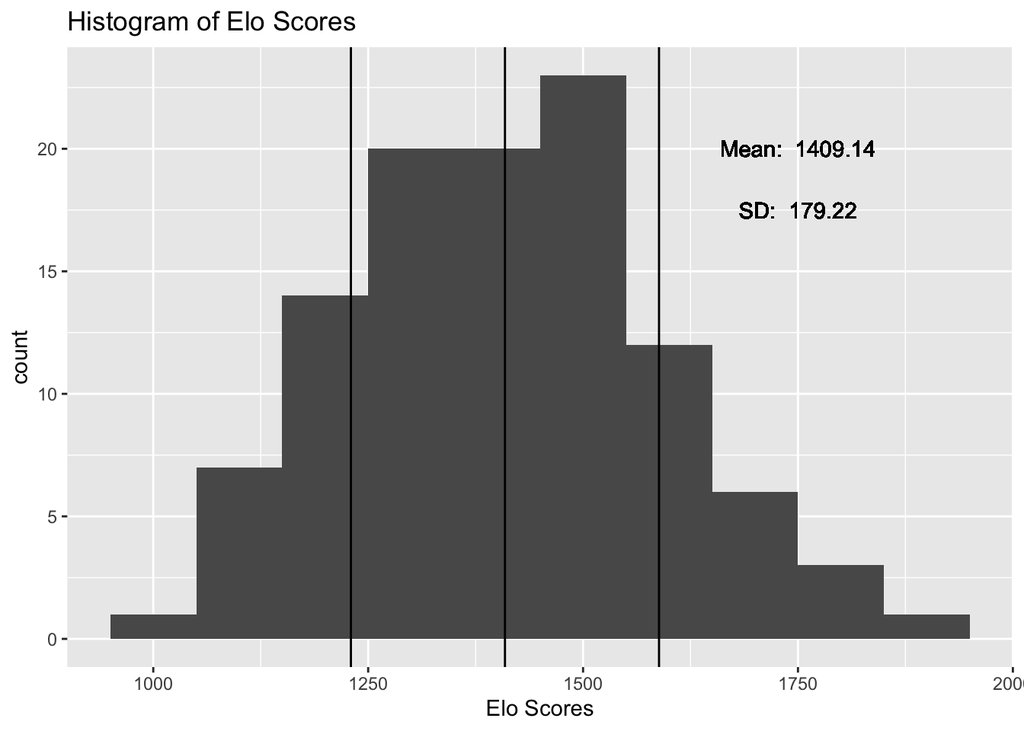

```r
level_data %>%
  ggplot(aes(elo)) +
  geom_histogram(binwidth = 100) +
  labs(
    title = "Histogram of Elo Scores",
    x = "Elo Scores") +
  geom_vline(aes(xintercept = mean(elo))) +
  geom_vline(aes(xintercept = mean(elo) + sd(elo))) +
  geom_vline(aes(xintercept = mean(elo) - sd(elo))) +
  geom_text(aes(x = 1750,
                y = 20,
                label = paste("Mean: ",round(mean(elo),2)))) +
  geom_text(aes(x = 1750,
                y = 17.5,
                label = paste("SD: ",round(sd(elo),2))))
```

## Relationship Between Elo and Physics Expert Ratings (GMPU)

The GMPU scores are expert ratings of level difficulty. Physics experts, researchers, and designers played the levels and scored them based on how difficult the level was to complete using the four different simple machines (e.g., lever, pendulum, etc.). There are separate ratings for each machine, but in the current version either the max or an average score is used. Overall, most levels have little variation in their GMPU scores (i.e., most have the same level for all machine). *Cleaning up the average scores for each is on the to do list, but we need to find more complete records of those scores*

To date, we have a few variations. I’m still trying to find a small number of levels’ GMPU, so there are missing data points. However, those levels are not one’s being used recently or in the near future. The levels still missing GMPU scores are:

- *UFO2*
- *You Again!* — only played once ever
- *Swamp People* — only played once ever
- *Wedge* — only played twice ever
- *Lead the Ball*

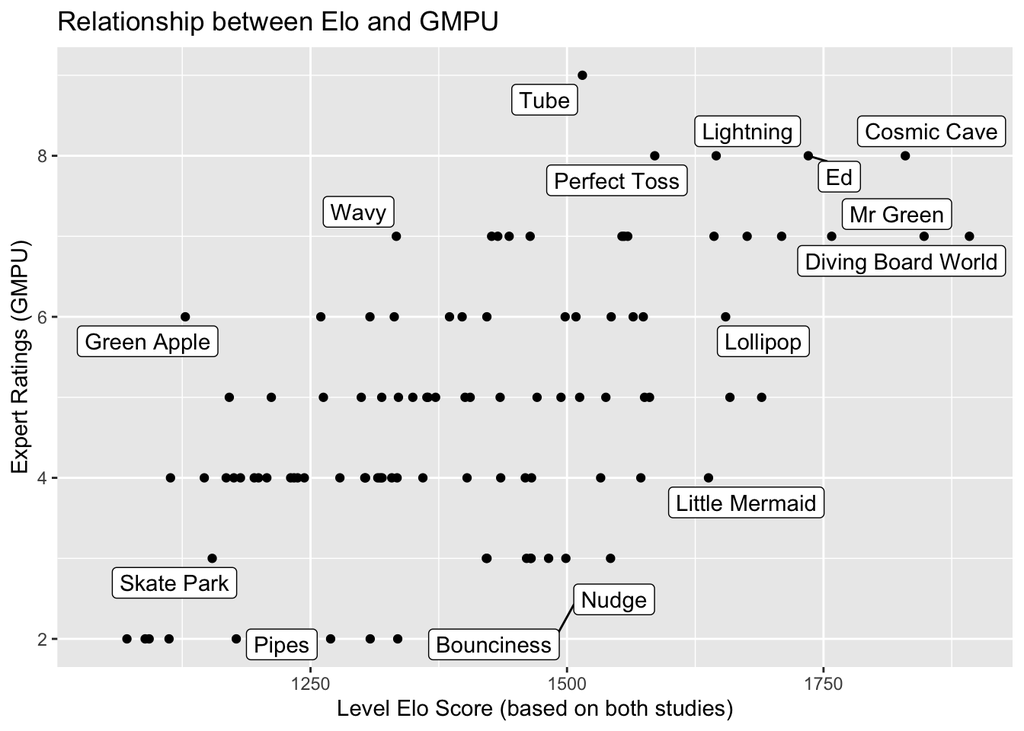

```r
level_data %>%
  ggplot(aes(x = elo, y = gmpu, label = level)) +
  geom_point() +
  geom_label_repel(max.overlaps = 5) +
  labs(
    title = 'Relationship between Elo and GMPU',
    x = 'Level Elo Score (based on both studies)',
    y = 'Expert Ratings (GMPU)'
  )
```

There is a linear relationship between the two, but it doesn’t seem all that strong. Because GMPU is ordinal, I used Spearman’s Rho below to test the correlation and found a correlation of $\rho$ = 0.51, *p* = 3.73e-08.

```r
cor.test(level_data$elo, level_data$gmpu,
         method = c("spearman"),
         use = 'complete.obs') ## Use complete.obs removes NA observations
```

```
##
##  Spearman's rank correlation rho
##
## data:  level_data$elo and level_data$gmpu
## S = 86262, p-value = 3.73e-08
## alternative hypothesis: true rho is not equal to 0
## sample estimates:
##       rho
## 0.5122324
```

So, we have decent agreement between the GMPU and Elo scores for levels. It’s medium, but significant. However, the general recollection was that GMPU was highly correlated with the mean duration to solve a level. That’s next.

## Elo Compared with External Measures

There are multiple angles I want to look at with the duration values. I’ve pulled out the mean duration (in seconds) spent {playing each level (mean_Dur_total), the mean duration spent to solve a level (mean_Dur_solved), and the mean duration spent on levels left unsolved (mean_Dur_unsolved).

I am also including, here and there, the total number of times a level was played, solved, and left unsolved ($n_{unsolved} + n_{solved} = n_{played}$).

```r
level_data %>%
  select(n_unsolved:gmpu) %>%
    cor(., use = 'complete.obs',
      method = 'spearman') %>%
  round(., 3)
```

```
##                   n_unsolved n_solved n_played mean_Dur_total mean_Dur_solved
## n_unsolved             1.000    0.557    0.802          0.420           0.416
## n_solved               0.557    1.000    0.926         -0.247          -0.248
## n_played               0.802    0.926    1.000          0.022           0.020
## mean_Dur_total         0.420   -0.247    0.022          1.000           0.999
## mean_Dur_solved        0.416   -0.248    0.020          0.999           1.000
## mean_Dur_unsolved      0.396   -0.218    0.032          0.868           0.856
## elo                    0.398   -0.413   -0.115          0.766           0.766
## gmpu                  -0.012   -0.425   -0.269          0.624           0.629
##                   mean_Dur_unsolved    elo   gmpu
## n_unsolved                    0.396  0.398 -0.012
## n_solved                     -0.218 -0.413 -0.425
## n_played                      0.032 -0.115 -0.269
## mean_Dur_total                0.868  0.766  0.624
## mean_Dur_solved               0.856  0.766  0.629
## mean_Dur_unsolved             1.000  0.686  0.548
## elo                           0.686  1.000  0.506
## gmpu                          0.548  0.506  1.000
```

### n_unsolved

However, there is very little difference between the total number of times a level was played and the number of times it was solved.

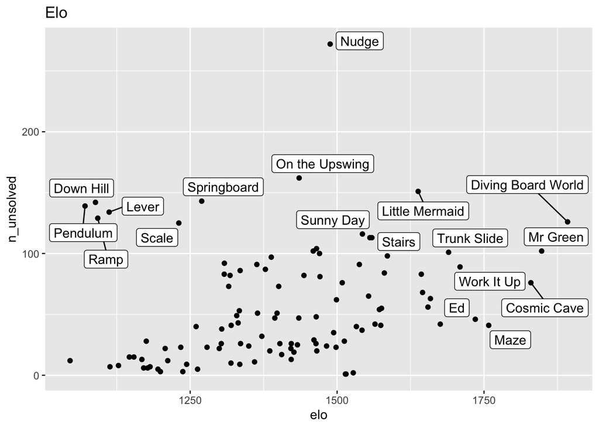

```r
level_data %>%
  ggplot(aes(x = elo,
             y = n_unsolved,
             label = level)) +
  geom_point() +
  geom_label_repel(max.overlaps = 10) +
  labs (
    title = "Elo")
```

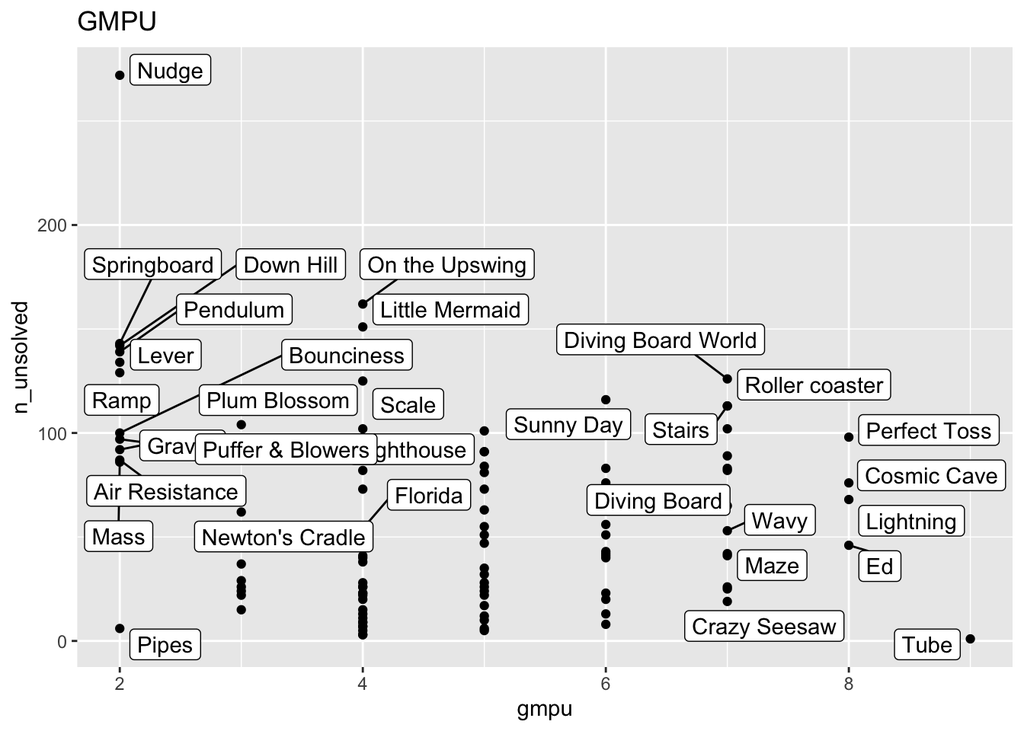

```r
level_data %>%
  ggplot(aes(x = gmpu,
             y = n_unsolved,
             label = level)) +
  geom_point() +
  geom_label_repel(max.overlaps = 10) +
  labs (
    title = "GMPU")
```

Looking at the two scatterplots above, the tutorial levels are creating some noise in the data. Removing them is likely warranted, but I don’t have a concrete list of which levels were used as tutorial levels in either study. I’m fairly certain Down HIll, Lever, and the other in that group and Nudge are. But I’ll wait until I can confirm to remove them.

Either way, I’m looking at number of times a level is left unsolved as a proxy of level difficulty because of the assumption that harders levels are more often left unsolved. Tutorial levels are an exception. These are levels that are more often skipped simply because they are too easy or just shown when the game is first loaded. Therefore, I would anticipate removing tutorial levels would only improve the correlation between Elo and n_unsolved.

### Mean Duration on SOLVED levels

Across the mean duration variables Elo and GMPU are nearly identically correlated with duration variable. And Elo has a consistently high correlation with duration variables than GMPU (by about 0.142). The mean duration to solve a level is most interesting. The mean duration spent on **unsolved** levels likely has a slight negative skew due to levels that are left unsolved without genuine effort to solve. I am already confident about the correlation above, but still want to see the scatterplot and add the n_unsolved for comparison.

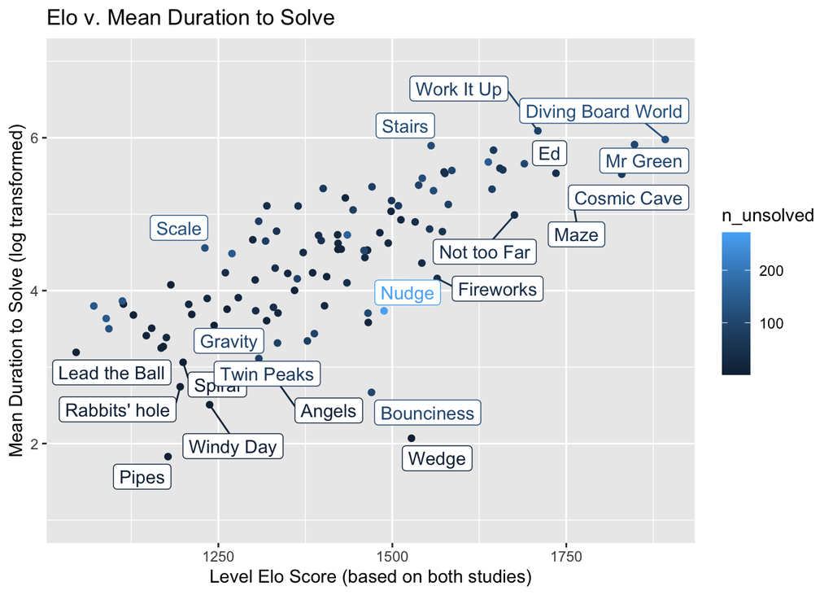

```r
level_data %>%
  ggplot(aes(x = elo,
             y = log(mean_Dur_solved),
             label = level,
             color = n_unsolved)) +
  geom_point() +
  geom_label_repel(max.overlaps = 15) +
  labs(
    title = 'Elo v. Mean Duration to Solve',
    x = 'Level Elo Score (based on both studies)',
    y = 'Mean Duration to Solve (log transformed)'
  ) + ylim(1,7)
```

## Other Questions

### What do the datasets look like

```r
#head(plutoObs, 0)
```

```r
head(level_data, 10)
```

```
## # A tibble: 10 x 9
##    level n_unsolved n_solved n_played mean_Dur_total mean_Dur_solved
##    <chr>      <int>    <int>    <int>          <dbl>           <dbl>
##  1 Air …         87      266      353           27.8            28.3
##  2 Ange…          9       38       47           17.2            16.7
##  3 Arou…         82      283      365          104.            104.
##  4 Back…         38      194      232           41.0            42.0
##  5 Bala…          6       67       73           26.1            26.3
##  6 Base…         24       47       71          114.            116.
##  7 Big …         55       62      117          254.            253.
##  8 Bloc…          5       52       57           41.2            42.8
##  9 Bloc…         10       48       58           36              36.8
## 10 Boun…        100      266      366           14.4            14.4
## # … with 3 more variables: mean_Dur_unsolved <dbl>, elo <dbl>, gmpu <dbl>
```

### What are the *p*-values for correlations

```r
cor.test(level_data$elo, level_data$gmpu)
```

```
##
##  Pearson's product-moment correlation
##
## data:  level_data$elo and level_data$gmpu
## t = 6.6065, df = 100, p-value = 1.931e-09
## alternative hypothesis: true correlation is not equal to 0
## 95 percent confidence interval:
##  0.3995768 0.6734953
## sample estimates:
##       cor
## 0.5512178
```

```r
cor.test(level_data$elo, level_data$mean_Dur_solved)
```

```
##
##  Pearson's product-moment correlation
##
## data:  level_data$elo and level_data$mean_Dur_solved
## t = 12.277, df = 102, p-value < 2.2e-16
## alternative hypothesis: true correlation is not equal to 0
## 95 percent confidence interval:
##  0.6809709 0.8399400
## sample estimates:
##       cor
## 0.7722773
```

```r
cor.test(level_data$gmpu, level_data$mean_Dur_solved)
```

```
##
##  Pearson's product-moment correlation
##
## data:  level_data$gmpu and level_data$mean_Dur_solved
## t = 7.7759, df = 99, p-value = 7.227e-12
## alternative hypothesis: true correlation is not equal to 0
## 95 percent confidence interval:
##  0.4778334 0.7240688
## sample estimates:
##       cor
## 0.6157677
```

### Do the correlations change within the construct (PoT, EcT, etc.)?

I need to bring in the data identifying the primary construct for each level.

### How do player Elo and level Elo scores compare?

```r
# elo_level <- elo_scores %>% filter(grp == 'level')
# elo_player <- elo_scores %>% filter(grp == 'player')
#
# ggplot() +
#   geom_histogram(data = elo_player, aes(elo, fill = 'blue')) +
#   geom_histogram(data = elo_level, alpha = 0.4, aes(elo, fill = 'green')) +
#   scale_fill_discrete(name = 'Group', labels = c('Player','Levels'))
```